# Exercise #2

Theresa Walter

12.01.2022

### Loaded packages

```r
library(tidyverse)
library(lubridate)
library(zoo)
```

## 1. Quality control procedures (4 QCPs)

```r
data <- read_csv('https://raw.githubusercontent.com/data-hydenv/data/master/hobo/2022/10_minute/10760710.csv',
         show_col_types = FALSE)

data
```

```
## # A tibble: 4,032 x 4
##       id dttm                 temp   lux
##    <dbl> <dttm>              <dbl> <dbl>
##  1     1 2021-12-13 00:00:00  5.24     0
##  2     2 2021-12-13 00:10:00  5.24     0
##  3     3 2021-12-13 00:20:00  5.24     0
##  4     4 2021-12-13 00:30:00  5.24     0
##  5     5 2021-12-13 00:40:00  5.35     0
##  6     6 2021-12-13 00:50:00  5.35     0
##  7     7 2021-12-13 01:00:00  5.45     0
##  8     8 2021-12-13 01:10:00  5.55     0
##  9     9 2021-12-13 01:20:00  5.55     0
## 10    10 2021-12-13 01:30:00  5.55     0
## # ... with 4,022 more rows
```

### 1.1 Measurement range (Plausible values)

The measurement range of HOBO is for temperature from -20°C to 70°C in air.

```r
data <- data %>%
    mutate(qcp1 = case_when(temp < -20 ~ 1, # flagging values < -20°C
          temp > 70 ~ 1, # flagging values > 70°C
          TRUE ~ 0))

data
```

```
## # A tibble: 4,032 x 5
##       id dttm                 temp   lux  qcp1
##    <dbl> <dttm>              <dbl> <dbl> <dbl>
##  1     1 2021-12-13 00:00:00  5.24     0     0
##  2     2 2021-12-13 00:10:00  5.24     0     0
##  3     3 2021-12-13 00:20:00  5.24     0     0
##  4     4 2021-12-13 00:30:00  5.24     0     0
##  5     5 2021-12-13 00:40:00  5.35     0     0
##  6     6 2021-12-13 00:50:00  5.35     0     0
##  7     7 2021-12-13 01:00:00  5.45     0     0
##  8     8 2021-12-13 01:10:00  5.55     0     0
##  9     9 2021-12-13 01:20:00  5.55     0     0
## 10    10 2021-12-13 01:30:00  5.55     0     0
## # ... with 4,022 more rows
```

Counting values with and without a flag for quality check 1:

```r
data %>% group_by(qcp1) %>% # groub by flag and no flag
    summarise(n = n()) %>%  # count values with and without flag
    ungroup()
```

```
## # A tibble: 1 x 2
##    qcp1     n
##   <dbl> <int>
## 1     0  4032
```

**Question**: How many data points are outside the measurement range?

**Answer**: There are 4032 values inside the measurement range and 0 unplausible values.

### 1.2 Plausible rate of change

Is there a difference of more than 1 K between two consecutive temperature values?

```r
data <- data %>% mutate(qcp2 = if_else(abs(temp - lag(temp)) > 1 , # Difference of temperature value and the previous temperature value
                       1, 0)) #flagging values with big difference to their previous value

data
```

```
## # A tibble: 4,032 x 6
##       id dttm                 temp   lux  qcp1  qcp2
##    <dbl> <dttm>              <dbl> <dbl> <dbl> <dbl>
##  1     1 2021-12-13 00:00:00  5.24     0     0    NA
##  2     2 2021-12-13 00:10:00  5.24     0     0     0
##  3     3 2021-12-13 00:20:00  5.24     0     0     0
##  4     4 2021-12-13 00:30:00  5.24     0     0     0
##  5     5 2021-12-13 00:40:00  5.35     0     0     0
##  6     6 2021-12-13 00:50:00  5.35     0     0     0
##  7     7 2021-12-13 01:00:00  5.45     0     0     0
##  8     8 2021-12-13 01:10:00  5.55     0     0     0
##  9     9 2021-12-13 01:20:00  5.55     0     0     0
## 10    10 2021-12-13 01:30:00  5.55     0     0     0
## # ... with 4,022 more rows
```

Counting values with and without a flag for quality check 2:

```r
data %>% group_by(qcp2) %>% # groub by flag and no flag
    summarise(n = n()) %>%  # count values with and without flag
    ungroup()
```

```
## # A tibble: 3 x 2
##    qcp2     n
##   <dbl> <int>
## 1     0  4024
## 2     1     7
## 3    NA     1
```

There are 7 inplausible temperature values:

```r
data %>% filter(qcp2 == 1)
```

```
## # A tibble: 7 x 6
##      id dttm                 temp   lux  qcp1  qcp2
##   <dbl> <dttm>              <dbl> <dbl> <dbl> <dbl>
## 1  1499 2021-12-23 09:40:00  1.98  312.     0     1
## 2  1500 2021-12-23 09:50:00  3.47  409      0     1
## 3  2679 2021-12-31 14:20:00 15.3  1001      0     1
## 4  2942 2022-01-02 10:10:00  9.96  581.     0     1
## 5  2943 2022-01-02 10:20:00 12.0   484.     0     1
## 6  3273 2022-01-04 17:20:00 11.0     0      0     1
## 7  3350 2022-01-05 06:10:00  5.14    0      0     1
```

**Question**: Describe shortly how many data points failed during this QCP and discuss whether there is a certain daytime pattern of failure or not?

### 1.3 Minimum variability (Persistence)

Didn’t the temperature value chanche during one hour?

```r
data <- data %>% mutate(qcp3 = if_else(temp == lag(temp, n = 1) &
                        temp == lag(temp, n = 2) &
                        temp == lag(temp, n = 3) &
                        temp == lag(temp, n = 4) &
                        temp == lag(temp, n = 5),
                       1, 0))

data
```

```
## # A tibble: 4,032 x 7
##       id dttm                 temp   lux  qcp1  qcp2  qcp3
##    <dbl> <dttm>              <dbl> <dbl> <dbl> <dbl> <dbl>
##  1     1 2021-12-13 00:00:00  5.24     0     0    NA    NA
##  2     2 2021-12-13 00:10:00  5.24     0     0     0    NA
##  3     3 2021-12-13 00:20:00  5.24     0     0     0    NA
##  4     4 2021-12-13 00:30:00  5.24     0     0     0    NA
##  5     5 2021-12-13 00:40:00  5.35     0     0     0     0
##  6     6 2021-12-13 00:50:00  5.35     0     0     0     0
##  7     7 2021-12-13 01:00:00  5.45     0     0     0     0
##  8     8 2021-12-13 01:10:00  5.55     0     0     0     0
##  9     9 2021-12-13 01:20:00  5.55     0     0     0     0
## 10    10 2021-12-13 01:30:00  5.55     0     0     0     0
## # ... with 4,022 more rows
```

Counting values with and without a flag for quality check 3:

```r
data %>%
    group_by(qcp3) %>% # groub by flag and no flag
    summarise(n = n()) %>%  # count values with and without flag
    ungroup()
```

```
## # A tibble: 3 x 2
##    qcp3     n
##   <dbl> <int>
## 1     0  3952
## 2     1    76
## 3    NA     4
```

There are 76 flagged values for quality check 3. Do they show a special pattern during a day?

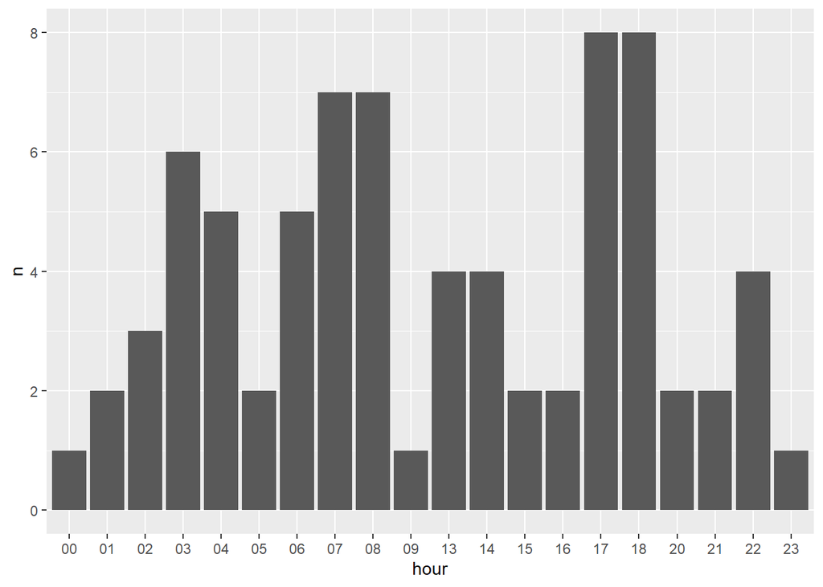

```r
data_unpersistant <- data %>% filter(qcp3 == 1) %>%
    mutate(hour = format(dttm, format="%H"))

dis_hour <- data_unpersistant %>%
    group_by(hour) %>% # groub by hour
    summarise(n = n()) %>%  # count values
    ungroup()
ggplot(dis_hour, aes(hour, n))+
    geom_col()
```

**Task**: Code in this section should analyses the persistance. If temperature has not changed during the last 60 minutes (i.e. data point Ti plus 5 data points before from Ti−1 to Ti−5) the corresponding data point Ti failed in this QCP.

**Answer**: The dataset contains 76 values, which have the same tamperature value as their 5 previous values and therefore failed the quality check 3. Those values show no specific pattern over one day.

### 1.4 Light intensity

Are temperature values influenced by intense sunlight?

```r
data <- data %>%
    mutate(sic = case_when(lux < 20000 ~ "cat1",
                       between(lux, 20000, 50000) ~ "cat2",
                       lux > 50000 ~ "cat3",
                       TRUE ~ "other")) %>%  # classify by Sky Illuminance Classes (cat 3 = intense sunlight, cat 2 = sunlight, cat 1 = no influence)
    mutate(qcp4 = case_when(
                (hour(dttm) < 6 & hour(dttm) >= 18) ~ 0, #set all qcp4 values for nighttime to 0
                           lag(sic, n = 3) == "cat3" ~ 1, #set 1 if cat3 +- 3 before or ahead
                           lag(sic, n = 2) == "cat3" ~ 1,
                           lag(sic) == "cat3" ~ 1,
                           sic == "cat2" ~ 1,
                           lead(sic) == "cat3" ~ 1,
                           lead(sic, n = 2) == "cat3" ~ 1,
                           lead(sic, n = 3) == "cat3" ~ 1,

                           lag(sic) == "cat2" ~ 1, #set 0 if cat 2 +- 1 before or ahead
                           sic == "cat2" ~ 1,
                           lead(sic) == "cat2" ~ 1,

                           TRUE ~ 0))

data
```

```
## # A tibble: 4,032 x 9
##       id dttm                 temp   lux  qcp1  qcp2  qcp3 sic    qcp4
##    <dbl> <dttm>              <dbl> <dbl> <dbl> <dbl> <dbl> <chr> <dbl>
##  1     1 2021-12-13 00:00:00  5.24     0     0    NA    NA cat1      0
##  2     2 2021-12-13 00:10:00  5.24     0     0     0    NA cat1      0
##  3     3 2021-12-13 00:20:00  5.24     0     0     0    NA cat1      0
##  4     4 2021-12-13 00:30:00  5.24     0     0     0    NA cat1      0
##  5     5 2021-12-13 00:40:00  5.35     0     0     0     0 cat1      0
##  6     6 2021-12-13 00:50:00  5.35     0     0     0     0 cat1      0
##  7     7 2021-12-13 01:00:00  5.45     0     0     0     0 cat1      0
##  8     8 2021-12-13 01:10:00  5.55     0     0     0     0 cat1      0
##  9     9 2021-12-13 01:20:00  5.55     0     0     0     0 cat1      0
## 10    10 2021-12-13 01:30:00  5.55     0     0     0     0 cat1      0
## # ... with 4,022 more rows
```

Counting values with and without a flag for quality check 4:

```r
data %>%
    group_by(sic) %>% # groub by categories
    summarise(n = n()) %>%  # count values with and without flag
    ungroup()
```

```
## # A tibble: 1 x 2
##   sic       n
##   <chr> <int>
## 1 cat1   4032
```

**Task**: Discuss shortly how often and when during daytime the QCP4 flags bad data. Elaborate on some reasons for your results.

**Answer**: The HOBO was attached to an interior balcony on the north side of the building. Therefore, it is plausible that no values were measured during direct sunlight.

## 2. Synthesis

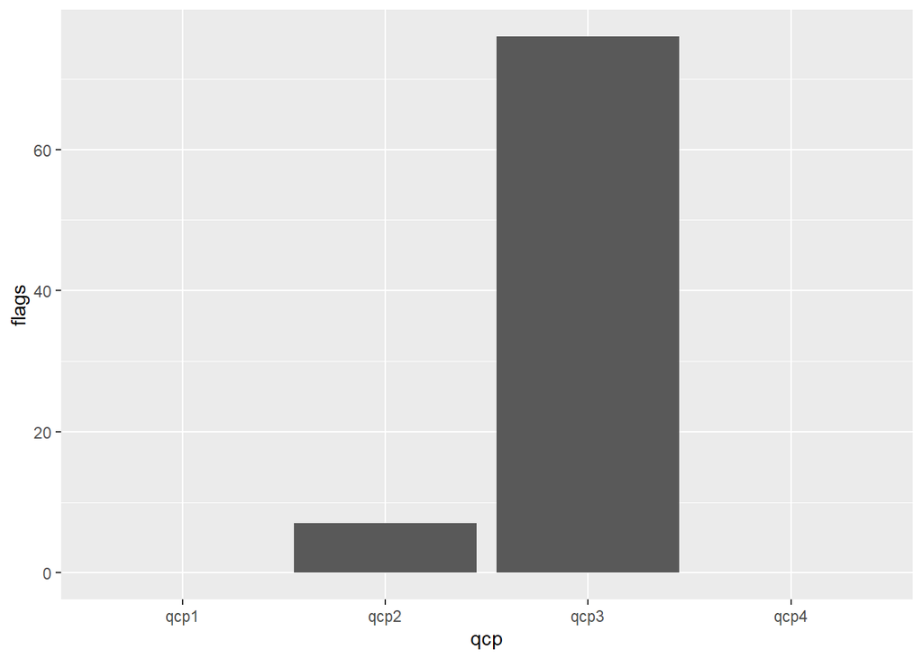

```
##    qcp flags
## 1 qcp1     0
## 2 qcp2     7
## 3 qcp3    76
## 4 qcp4     0
```

```r
synth <- data.frame(qcp = c("qcp1", "qcp2", "qcp3", "qcp4"),
            flags = c(sum(data$qcp1, na.rm = TRUE),
                  sum(data$qcp2, na.rm = TRUE),
                  sum(data$qcp3, na.rm = TRUE),
                  sum(data$qcp4, na.rm = TRUE)))
ggplot(synth, aes(qcp, flags))+
    geom_col()
```

**Task**: Present a table or graph to show how many data points fail during the four specific QCPs. Discuss shortly the reasons for failure and compare the different QCPs against each other.

**Answer**: As shown in the graph above, the most fails were detected during quality check 3. There were found 76 temperature values, which were same as their 5 previous values. In quality check 2 only 7 temperature values were detected, which differ more than 1 K from their previous value. No bad values were found in quality check 1 and 4. Fails in quality check 2 (strong change in temperature) might happended because of human influence by using the balkony. Fails in quality ckeck 3 are eventually caused by the slow reaction of temperature caused by the location of the HOBO at a inverted balcony where hardly any influence from wind etc. happens.

## 3. Results

### 3.1 Result (Flagging system: 10-minutes-values)

```r
# combine all important data with information about measurement and results from quality check
qc_df <- data.frame(id = data$id, dttm = data$dttm, temp = data$temp, lux = data$lux, qcp1 = data$qcp1, qcp2 = data$qcp2, qcp3 = data$qcp3, qcp4 = data$qcp4)

# summarize the qualiy cck resutls to one final flagging (flag_num)
qc_df <- qc_df %>%
mutate(qc_tot = qcp1 + qcp2 + qcp3) %>%
mutate(flag_num = if_else(qc_tot > 0, 1, 0)) %>%
mutate(flag_txt = if_else(qc_tot > 1, "bad", "good")) %>%
    as_tibble()

qc_df
```

```
## # A tibble: 4,032 x 11
##       id dttm                 temp   lux  qcp1  qcp2  qcp3  qcp4 qc_tot flag_num
##    <dbl> <dttm>              <dbl> <dbl> <dbl> <dbl> <dbl> <dbl>  <dbl>    <dbl>
##  1     1 2021-12-13 00:00:00  5.24     0     0    NA    NA     0     NA       NA
##  2     2 2021-12-13 00:10:00  5.24     0     0     0    NA     0     NA       NA
##  3     3 2021-12-13 00:20:00  5.24     0     0     0    NA     0     NA       NA
##  4     4 2021-12-13 00:30:00  5.24     0     0     0    NA     0     NA       NA
##  5     5 2021-12-13 00:40:00  5.35     0     0     0     0     0      0        0
##  6     6 2021-12-13 00:50:00  5.35     0     0     0     0     0      0        0
##  7     7 2021-12-13 01:00:00  5.45     0     0     0     0     0      0        0
##  8     8 2021-12-13 01:10:00  5.55     0     0     0     0     0      0        0
##  9     9 2021-12-13 01:20:00  5.55     0     0     0     0     0      0        0
## 10    10 2021-12-13 01:30:00  5.55     0     0     0     0     0      0        0
## # ... with 4,022 more rows, and 1 more variable: flag_txt <chr>
```

**Task**: At the end of the code section above you should generate one! tibble or data.frame named `qc_df` with all time information, all data points (temperature and lux) and your outcomes of the different QCPs.

### 3.2 Result (Aggregate to hourly series)

```r
hobo_hourly_dummy <- qc_df %>%
    mutate(hour = format(dttm, format="%Y-%m-%d %H")) %>%
    mutate(hour = cut(dttm, breaks = "hour")) %>%
    group_by(hour) %>%
    summarise_at(vars(temp, flag_num), ~ mean(.,na.rm = TRUE)) %>%
    mutate(temp_2 = if_else(flag_num < 0.3, temp, NULL))

hobo_hourly <- data.frame(dttm = hobo_hourly_dummy$hour, temp = round(hobo_hourly_dummy$temp_2, 4)) %>%
    as_tibble()

write.csv(hobo_hourly, 'C:/Users/Theresa/0-Studium/ALU/Semester 1/Modul 4 Data Collection Storage Management/Timeseries_in_R/Timeseries_in_R-1/1_data_processed/meteo_stations/my_hobo.csv', row.names = FALSE)

hobo_hourly
```

```
## # A tibble: 672 x 2
##    dttm                 temp
##    <fct>               <dbl>
##  1 2021-12-13 00:00:00  5.28
##  2 2021-12-13 01:00:00  5.54
##  3 2021-12-13 02:00:00  5.48
##  4 2021-12-13 03:00:00  5.19
##  5 2021-12-13 04:00:00  4.36
##  6 2021-12-13 05:00:00  4.10
##  7 2021-12-13 06:00:00  4.03
##  8 2021-12-13 07:00:00  3.51
##  9 2021-12-13 08:00:00  3.61
## 10 2021-12-13 09:00:00  3.84
## # ... with 662 more rows
```

**Task**: At the end of the code section above you should generate one! tibble or data.frame named `hobo_hourly` with averaged temperature values per hour or NA values (if the hour is flagged as bad data). See exercise description for more details.

- First column: YYYY-DD-MM HH:MM:SS
- Second column: Temperature values (4 digits), NA values possible